# Introdução à Ciência de Dados

Introdução à Inferência Estatística- Parte 2

Autor

Weverton Rodrigues

Data de Publicação

2 de julho de 2025

# 1 Estimação por Intervalo de Confiança

## 1.1 Por que Intervalos de Confiança?

O Desafio do Analista de Dados:

**Problema**: Uma estimativa pontual informa um valor, mas não quantifica a incerteza associada à inferência de uma amostra para a população.

**Exemplo**: Satisfação média de 7.2 pontos em amostra de 100 clientes.

**Pergunta**: Qual nossa confiança nesta estimativa?

**Solução**: Intervalos de confiança não reduzem a incerteza, mas a expressam de forma probabilisticamente controlada.

**Comunicação Correta**:

> “A satisfação média de todos os clientes está entre 6.8 e 7.6 pontos, com 95% de confiança.”

Quantifica a incerteza da amostragem.

# 2 Intervalos para Proporções

## 2.1 Aplicações para Proporções

Situações Práticas:

**Marketing**: Taxa de conversão, proporção de clientes satisfeitos, percentual de recomendação.

**Qualidade**: Taxa de defeitos, proporção de entregas no prazo, percentual de conformidade.

**Recursos Humanos**: Taxa de rotatividade, percentual de funcionários engajados.

**Pesquisa de Mercado**: Intenção de compra, preferência entre marcas, aceitação de produtos.

**Pesquisas Eleitorais**: Intenção de voto, aprovação de candidatos ou governos.

## 2.2 Exemplo 1: Intervalo de Confiança para 1 Proporção

### 2.2.1 Pesquisa Eleitoral

**Cenário**: Instituto de pesquisa realiza levantamento sobre intenção de voto para prefeito em cidade de 500.000 habitantes.

**Amostra**: 1.200 eleitores selecionados aleatoriamente **Resultado**: 456 eleitores declararam intenção de votar no Candidato A

**Objetivo**: Estimar a proporção populacional de intenção de voto com intervalo de confiança.

Exemplo 1 em R

```r
# dados da pesquisa eleitoral
n_eleitores <- 1200
votos_candidato_a <- 456

# estimativa pontual da proporção populacional
# ou simplemente proporção amostral
prop_amostral <- votos_candidato_a / n_eleitores
prop_amostral
```

```
[1] 0.38
```

Estimativa por Intervalo de confiança (95%) da proporção populacional:

```r
estimativa_ic_proporcao <- prop.test(x = votos_candidato_a,
                                 n = n_eleitores,
                                 conf.level = 0.95)

# exibe o resultado
estimativa_ic_proporcao
```

```
    1-sample proportions test with continuity correction

data:  votos_candidato_a out of n_eleitores, null probability 0.5
X-squared = 68.6, df = 1, p-value <0.0000000000000002
alternative hypothesis: true p is not equal to 0.5
95 percent confidence interval:
 0.35255 0.40823
sample estimates:
   p
0.38
```

Extrai somente a estimativa do intervalo de confiança

```r
estimativa_ic_proporcao$conf.int
```

```
[1] 0.35255 0.40823
attr(,"conf.level")
[1] 0.95
```

## 2.3 Exemplo 2: Intervalo de Confiança para Diferença entre 2 Proporções

### 2.3.1 Análise de Taxa de Conversão

Uma empresa de e-commerce testou duas estratégias de campanha publicitária digital. O analista de dados precisa comparar as taxas de conversão para determinar se existe diferença significativa entre as estratégias.

**Dados Coletados:**

| Campanha | Visualizações | Conversões | Taxa Observada |
| --- | --- | --- | --- |
| A (Tradicional) | 2.500 | 175 | 7.0% |
| B (Personalizada) | 2.200 | 198 | 9.0% |

**Objetivo da Análise:**

Construir um intervalo de 95% de confiança para a diferença entre as taxas de conversão e avaliar se há evidência estatística de diferença entre as campanhas.

Exemplo 2 em R

```r
# Dados das campanhas
# Campanha A (Tradicional)
n_a <- 2500
x_a <- 175

# Campanha B (Personalizada)
n_b <- 2200
x_b <- 198

# Calcula proporções amostrais
prop_a <- x_a / n_a
prop_b <- x_b / n_b

# Exibe as proporções amostrais
prop_a
```

```
[1] 0.07
```

```r
prop_b
```

```
[1] 0.09
```

Diferença observada (B - A)

```r
diferenca_observada <- prop_b - prop_a
diferenca_observada
```

```
[1] 0.02
```

Comparar as duas proporções: A função calcula (primeira - segunda), então usamos ordem (B, A) para obter (B - A)

```r
resultado <- prop.test(x = c(x_b, x_a), n = c(n_b, n_a), conf.level = 0.95)

# Exibir resultado completo
resultado
```

```
    2-sample test for equality of proportions with continuity correction

data:  c(x_b, x_a) out of c(n_b, n_a)
X-squared = 6.14, df = 1, p-value = 0.013
alternative hypothesis: two.sided
95 percent confidence interval:
 0.003983 0.036017
sample estimates:
prop 1 prop 2
  0.09   0.07
```

```r
# Extrair intervalo de confiança
ic_a_menos_b <- resultado$conf.int
ic_a_menos_b
```

```
[1] 0.003983 0.036017
attr(,"conf.level")
[1] 0.95
```

- **Interpretação:**

A diferença observada entre as taxas de conversão foi de 2.0 pontos percentuais a favor da Campanha B (9.0% versus 7.0%).

O intervalo de 95% de confiança para a verdadeira diferença indica que, com 95% de confiança, a diferença populacional está entre aproximadamente 0.4 e 3.6 pontos percentuais.

Como o intervalo de confiança não contém zero e todos os valores são positivos, existe evidência estatística de que a Campanha B possui taxa de conversão superior à Campanha A.

# 3 Intervalos para Médias

## 3.1 Aplicações para Médias

Variáveis Numéricas em Administração:

- **Análise Financeira**: Receita média por cliente, valor médio de transações, ROI médio (*com cautela* em caso de assimetrias).
- **Operações**: Tempo médio de produção, custo médio unitário, produção média por hora.
- **Marketing**: Valor médio de pedidos (ticket médio), tempo médio de conversão, número médio de cliques por campanha.
- **Recursos Humanos**: Salário médio por departamento, tempo médio de permanência (retenção).
- **Atendimento ao Cliente**: Tempo médio de resposta, pontuação média de satisfação (*em escalas tipo Likert*).

## 3.2 Exemplo 1 - Intervalo de Confiança para 1 Média

### 3.2.1 Tempo de Resposta de Suporte

**Situação**: Avaliar o tempo médio de resolução de tickets de suporte técnico.

```r
tempos <- c(2.1, 3.4, 1.8, 4.2, 2.9, 3.1, 2.7, 1.9, 3.8, 2.5,
            4.1, 2.3, 3.6, 2.8, 1.7, 3.9, 2.4, 3.2, 2.6, 4.0,
            1.6, 3.5, 2.2, 3.7, 2.0)

# cria um data frame com os tempos
dados_tempo <- data.frame(tempo = tempos)

# exibe a data frame
dados_tempo
```

```
   tempo
1    2.1
2    3.4
3    1.8
4    4.2
5    2.9
6    3.1
7    2.7
8    1.9
9    3.8
10   2.5
11   4.1
12   2.3
13   3.6
14   2.8
15   1.7
16   3.9
17   2.4
18   3.2
19   2.6
20   4.0
21   1.6
22   3.5
23   2.2
24   3.7
25   2.0
```

Gráfico quantil-quantil (QQ) para verificar a normalidade dos tempos de resposta:

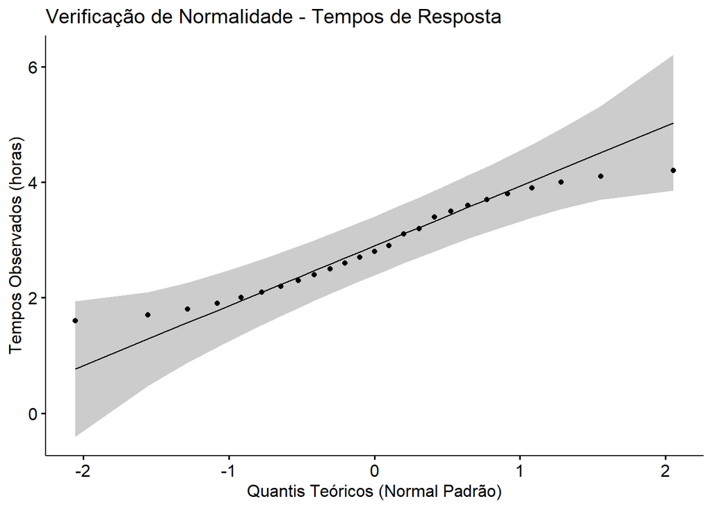

```r
ggqqplot(dados_tempo, x = "tempo") +
  labs(title = "Verificação de Normalidade - Tempos de Resposta",
       x = "Quantis Teóricos (Normal Padrão)",
       y = "Tempos Observados (horas)")
```

O gráfico QQ mostra que os dados estão razoavelmente próximos de uma distribuição normal, com dois pontos no limiar da banda cinza, mas sem grandes desvios.

```r
# média amostral
mean(tempos)
```

```
[1] 2.88
```

```r
# intervalo de confiança
resultado_tempo <- t.test(tempos, conf.level = 0.95)
resultado_tempo$conf.int
```

```
[1] 2.5409 3.2191
attr(,"conf.level")
[1] 0.95
```

**Resultado**: IC 95% = [2.5, 3.2] horas

**Conclusão**: Com 95% de confiança, o tempo médio de resolução está entre **2.5 e 3.2 horas**.

## 3.3 Exemplo 2: Teste A/B - IC para Diferença entre 2 Médias

#### 3.3.0.1 Teste de Duas Versões de Website

**Cenário**: Comparar tempo médio de permanência entre versão atual (A) e redesenhada (B).

```r
versao_a <- c(3.2, 4.1, 2.8, 3.9, 3.5, 4.3, 2.9, 3.7, 4.0, 3.3,
              2.6, 3.8, 4.2, 3.1, 3.6, 2.7, 4.5, 3.4, 2.5, 3.9)

versao_b <- c(4.8, 5.2, 4.3, 5.6, 4.7, 5.1, 4.9, 5.4, 4.5, 5.0,
              4.6, 5.3, 4.4, 5.7, 4.8, 5.5, 4.2, 5.8, 4.7, 5.2)

dados_ab <- data.frame(
  tempo = c(versao_a, versao_b),
  grupo = c(rep("A", 20), rep("B", 20))
)

# exibe a data frame
dados_ab
```

```
   tempo grupo
1    3.2     A
2    4.1     A
3    2.8     A
4    3.9     A
5    3.5     A
6    4.3     A
7    2.9     A
8    3.7     A
9    4.0     A
10   3.3     A
11   2.6     A
12   3.8     A
13   4.2     A
14   3.1     A
```

[output cut: 26 more lines]

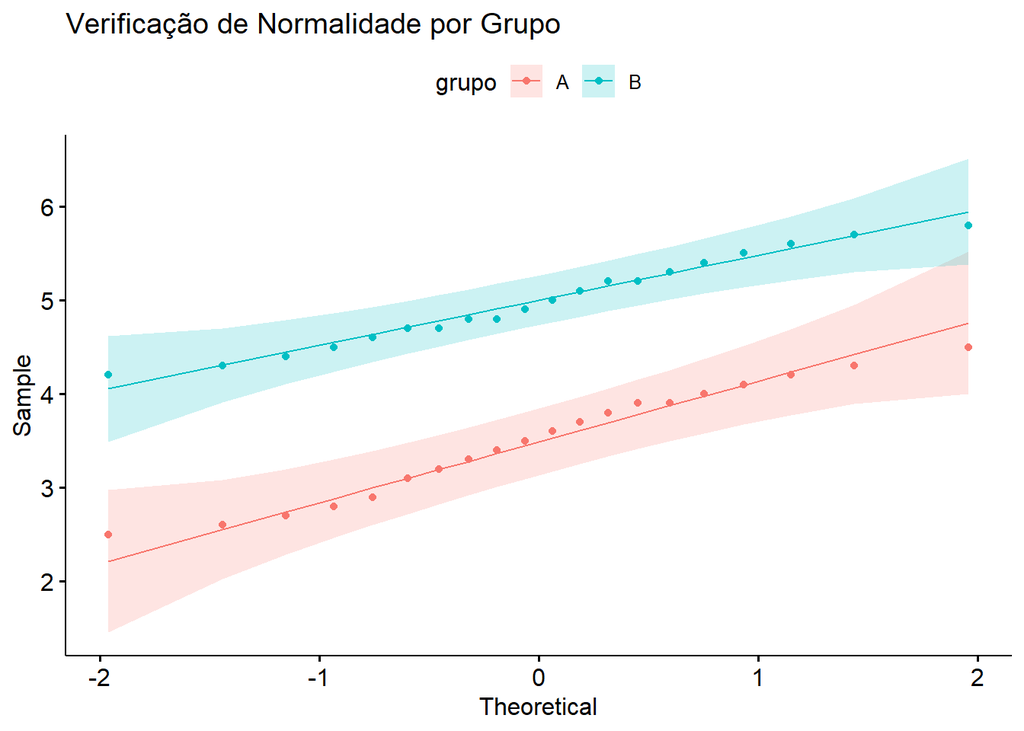

```r
ggqqplot(dados_ab, x = "tempo", color = "grupo") +
  labs(title = "Verificação de Normalidade por Grupo")
```

0 gráfico quantil-quantil (QQ) mostra que ambos os grupos estão razoavelmente próximos de uma distribuição normal.

```r
# intervalo de confiança para diferença de médias
resultado_ab <- t.test(versao_b, versao_a, conf.level = 0.95)
resultado_ab$conf.int
```

```
[1] 1.1393 1.8307
attr(,"conf.level")
[1] 0.95
```

**Resultado**: IC 95% para (B - A) = [1.14, 1.83] minutos

**Conclusão**: Com 95% de confiança, a nova versão aumenta o tempo médio de permanência entre **1.14 e 1.83 minutos**.

**Decisão**: Implementar Versão B em produção.

## 3.4 Exercício 1: Teste A/B

Uma empresa de varejo online conduziu um teste A/B para avaliar duas versões de e-mail promocional. O analista de dados precisa determinar se existe diferença significativa entre as taxas de cliques das duas versões.

**Dados Coletados:**

Durante uma semana, a empresa enviou aleatoriamente duas versões de e-mail promocional para sua base de clientes:

- Versão A (linha de assunto tradicional): 8.500 e-mails enviados, 612 cliques registrados
- Versão B (linha de assunto personalizada): 8.200 e-mails enviados, 697 cliques registrados

**Questões para Análise:**

1. Estime as taxas de cliques amostrais para cada versão e a diferença observada.

```r
# seu código aqui
```

2. Obtenha uma estimativa de um intervalo de 95% de confiança para a diferença entre as taxas de cliques (B - A).

```r
# seu código aqui
```

3. Interprete os resultados e faça uma recomendação.

## 3.5 Exercício 2: Tempo de Atendimento

O departamento de atendimento ao cliente de uma empresa de telecomunicações implementou um novo sistema de triagem automatizada. O gerente de operações deseja comparar o tempo médio de resolução de chamadas entre o método tradicional e o novo sistema automatizado.

**Dados Experimentais:**

Durante um mês, foram coletados aleatoriamente tempos de resolução (em minutos) de chamadas atendidas pelos dois métodos:

```r
# Dados já organizados para facilitar a análise
tradicional <- c(12, 15, 18, 14, 22, 16, 13, 19, 17, 21, 14, 16, 20,
                 18, 15, 23, 17, 14, 19, 16, 18, 15, 20, 17, 16)

automatizado <- c(10, 12, 14, 11, 16, 13, 9, 15, 12, 18, 11, 14, 13,
                  10, 17, 12, 15, 11, 13, 16, 14, 12, 15, 13, 11, 17, 14, 12)

# Cria a data frame para armazenamento dos dados
dados_atendimento <- data.frame(
  tempo = c(tradicional, automatizado),
  metodo = c(rep("Tradicional", length(tradicional)),
             rep("Automatizado", length(automatizado)))
)
```

**Tarefas:**

1. Verifique a normalidade dos dados usando gráficos quantil-quantil

```r
# seu código aqui
```

2. Estime os tempos médios amostrais de resolução para cada método e a diferença observada entre eles.

```r
# seu código aqui
```

3. Obtenha uma estimativa de um intervalo de 95% de confiança para a diferença entre os tempos médios

```r
# seu código aqui
```

4. Interprete os resultados e faça uma recomendação.